# Configuration

## Per-sequence k-mer stats

**Total k-mers per sequence**  
Should be consistent with the distribution of sequence lengths

```python
for k in ks_plot:
    print(k)
    pprint(Counter(np.asarray(kmer_data[k]["kmer_matrix"].sum(axis=1)).squeeze()))
    print()
```

```
2
Counter({169.0: 17437})

3
Counter({168.0: 17437})

4
Counter({167.0: 17437})

6
Counter({165.0: 17437})

8
Counter({163.0: 17437})

10
Counter({161.0: 17437})
```

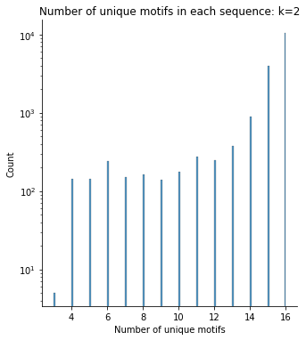

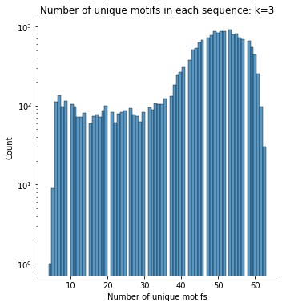

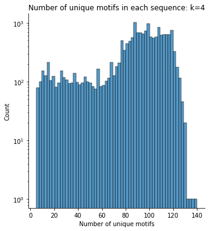

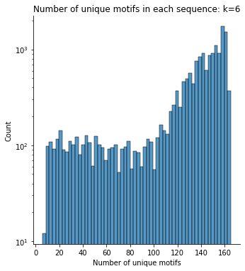

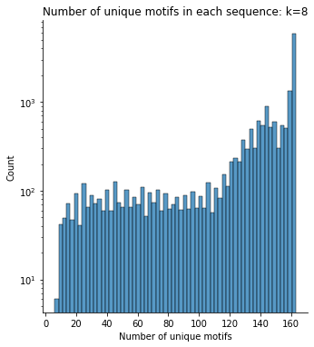

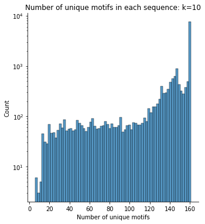

```python
for k in ks_plot:
    sns.displot(x=np.asarray((kmer_data[k]["kmer_matrix"] > 0).sum(axis=1)).squeeze())
    plt.gca().set_yscale("log")
    plt.gca().set_title(f"Number of unique motifs in each sequence: k={k}")
    plt.gca().set_xlabel(f"Number of unique motifs")
```

Pairwise distances

```python
def sample_distances(kmer_matrix):
    pass
```

TODO: Plot where each sequence is a line. x-axis is the numbered set of observed k-mers, so it will be the same for each oligo. The y-axis counts the cumulative number of unique k-mers observed, as you progress from the most common kmer to the least common. A sequence with each kmer being unique will basically be the identity line, while a sequence with a single kmer dominating will have a long horizontal stretch.

## Clustering

Perform initial clustering with k = 6.

```python
k = 6
nns = NearestNeighbors(n_neighbors=10, n_jobs=-1)
nns.fit(kmer_data[k]["kmer_matrix"])
knn_matrix = nns.kneighbors_graph()
adj_graph = ig.Graph.Weighted_Adjacency(knn_matrix * knn_matrix.T)
partition = leidenalg.find_partition(adj_graph, leidenalg.ModularityVertexPartition, n_iterations=-1)
```

## Embedding

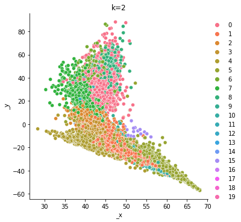

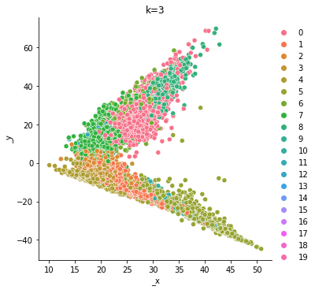

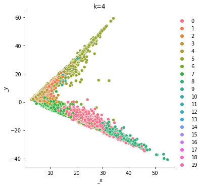

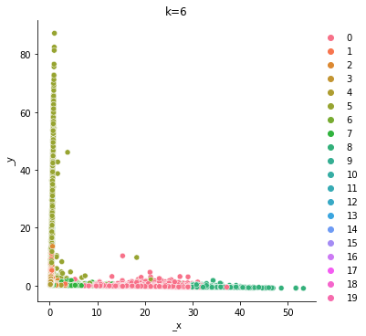

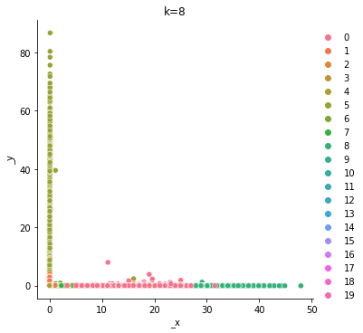

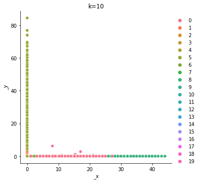

```python
for k in tqdm(ks_plot):
    svd = TruncatedSVD(2).fit_transform(kmer_data[k]["kmer_matrix"])
    sns.relplot(x=svd[:, 0], y=svd[:, 1], hue=pd.Categorical(partition.membership))
    plt.gca().set_title(f"k={k}")
```

Fourier components of the one-hot sequences.

Iterate over seqs and compute how many times all kmers observed and fraction of all possible kmers

# Motifs

```python
motifs_df = pd.read_table(
    motif_path,
    header=None,
    names=[
        "PB_ID",
        "source",
        "feature",
        "start",
        "end",
        "score",
        "strand",
        "phase",
        "attributes",
    ],
    comment="#",
).assign(
    motif_name=lambda x: x["attributes"]
    .str.split(";")
    .str[0]
    .str.split()
    .str[1]
    .str.strip('"'),
    motif_instance=lambda x: x["attributes"]
    .str.split(";")
    .str[1]
    .str.split()
    .str[1]
    .str.strip('"'),
)
```

```python
motifs_df.sort_values(by="score", ascending = False)
```

|  | PB_ID | source | feature | start | end | score | strand | phase | attributes | motif_name | motif_instance |
| --- | --- | --- | --- | --- | --- | --- | --- | --- | --- | --- | --- |
| 1231315 | PB-TL-0021-005208 | pfmscan | misc_feature | 134 | 163 | 35.194655 | - | . | motif_name "GM.5.0.Nuclear_receptor.0116" ; mo... | GM.5.0.Nuclear_receptor.0116 | CTCTGTCACCCAGGCTGGAGTGCAGTGGCA |
| 1244552 | PB-TL-0002-0081871 | pfmscan | misc_feature | 103 | 132 | 35.194655 | - | . | motif_name "GM.5.0.Nuclear_receptor.0116" ; mo... | GM.5.0.Nuclear_receptor.0116 | CTCTGTCACCCAGGCTGGAGTGCAGTGGCA |
| 1244765 | PB-TL-0002-0023051 | pfmscan | misc_feature | 14 | 43 | 35.194655 | + | . | motif_name "GM.5.0.Nuclear_receptor.0116" ; mo... | GM.5.0.Nuclear_receptor.0116 | TGCCACTGCACTCCAGCCTGGGTGACAGAG |
| 159098 | PB-TL-0030-009339 | pfmscan | misc_feature | 127 | 156 | 34.908657 | + | . | motif_name "GM.5.0.Nuclear_receptor.0116" ; mo... | GM.5.0.Nuclear_receptor.0116 | CGCCACTGCACTCCAGCCTGGGTGACAGAG |
| 1172921 | PB-TL-0030-009122 | pfmscan | misc_feature | 42 | 71 | 33.787129 | + | . | motif_name "GM.5.0.Unknown.0113" ; motif_insta... | GM.5.0.Unknown.0113 | AACATGGTGAAACCCCGTCTCTACTAAAAA |
| ... | ... | ... | ... | ... | ... | ... | ... | ... | ... | ... | ... |
| 1221452 | PB-TL-0018-008698 | pfmscan | misc_feature | 15 | 44 | -22.316090 | - | . | motif_name "GM.5.0.Unknown.0148" ; motif_insta... | GM.5.0.Unknown.0148 | TTCGAGACCACCCATGGTCAACCAACATGG |
| 944091 | PB-TL-0030-003104 | pfmscan | misc_feature | 100 | 129 | -22.433822 | + | . | motif_name "GM.5.0.Unknown.0148" ; motif_insta... | GM.5.0.Unknown.0148 | CCTGGTTAGCTGTGGTGGAGCAGTGCTGAC |
| 1040178 | PB-TL-0030-006780 | pfmscan | misc_feature | 2 | 31 | -22.497833 | - | . | motif_name "GM.5.0.Unknown.0148" ; motif_insta... | GM.5.0.Unknown.0148 | TTCAAAGGCACGAGAGGAGCAGCAACGTGT |
| 421069 | PB-TL-0030-006091 | pfmscan | misc_feature | 18 | 47 | -22.497833 | - | . | motif_name "GM.5.0.Unknown.0148" ; motif_insta... | GM.5.0.Unknown.0148 | AGCAAAAGCACCAGGGGGCCAGCAAGATGG |
| 708037 | PB-TL-0030-003670 | pfmscan | misc_feature | 125 | 154 | -22.533345 | + | . | motif_name "GM.5.0.Unknown.0148" ; motif_insta... | GM.5.0.Unknown.0148 | CCAGGTTTTTTTCTTTTTAATTTTTTTTTT |

1251800 rows × 11 columns

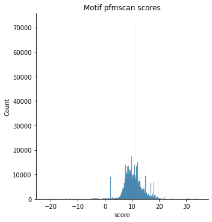

```python
sns.displot(data=motifs_df, x="score")
plt.title("Motif pfmscan scores")
```

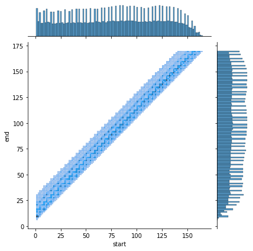

```python
sns.jointplot(data=motifs_df, x="start", y="end", kind="hist")
```

```python
motifs_crosstab = pd.crosstab(motifs_df["PB_ID"], motifs_df["motif_name"])
motifs_matrix = motifs_crosstab.values
```

**Number of motif matches per sequences**

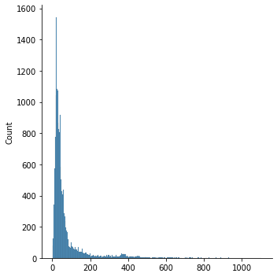

```python
sns.displot(motifs_matrix.sum(axis=1))
```

**Number of unique motifs in each sequence**

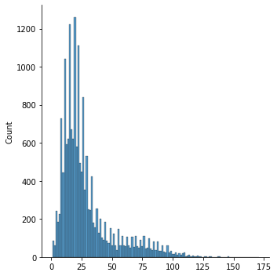

```python
sns.displot((motifs_matrix > 0).sum(axis=1))
```

**Number of times each motif is observed across the library**

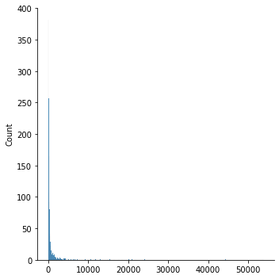

```python
sns.displot(motifs_matrix.sum(axis=0))
```

**Number of oligos each motif is observed in**

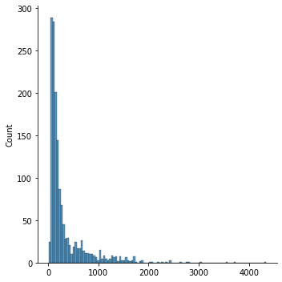

```python
sns.displot((motifs_matrix > 0).sum(axis=0))
```

**Most common motifs**

```python
motifs_crosstab.sum(axis=0).nlargest(10)
```

```
motif_name
GM.5.0.Forkhead.0032    53743
GM.5.0.C2H2_ZF.0067     44340
GM.5.0.C2H2_ZF.0066     24132
GM.5.0.C2H2_ZF.0082     21924
GM.5.0.C2H2_ZF.0141     21062
GM.5.0.C2H2_ZF.0065     20979
GM.5.0.Rel.0018         20235
GM.5.0.C2H2_ZF.0145     20163
GM.5.0.C2H2_ZF.0237     18493
GM.5.0.C2H2_ZF.0297     17723
dtype: int64
```

**Sequences with the most and fewest motifs**

```python
motifs_crosstab.sum(axis=1).nlargest(10)
```

```
PB_ID
PB-TL-0030-001397    1104
PB-TL-0030-001391    1095
PB-TL-0030-010313    1062
PB-TL-0030-001379    1040
PB-TL-0030-001382    1033
PB-TL-0030-001390     991
PB-TL-0030-001406     989
PB-TL-0030-001393     958
PB-TL-0030-001405     945
PB-TL-0030-001594     942
dtype: int64
```

```python
motifs_crosstab.sum(axis=1).nsmallest(10)
```

```
PB_ID
PB-TL-0030-005212    1
PB-TL-0030-005378    1
PB-TL-0030-005419    1
PB-TL-0030-005451    1
PB-TL-0030-006154    1
PB-TL-0030-006562    1
PB-TL-0030-013655    1
PB-TL-0030-003793    2
PB-TL-0030-004934    2
PB-TL-0030-005218    2
dtype: int64
```

**TODO**: plot a few sequences along with their motif overlays. Also plot the sequences with the most motifs.

## Embedding

```python
import scanpy as sc
```

[output not shown]

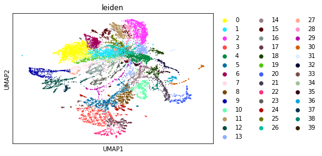

```python
adata = sc.AnnData(motifs_matrix)
sc.pp.neighbors(adata)

sc.tl.louvain(adata, key_added = "leiden")
sc.tl.umap(adata)
sc.pl.umap(adata, color = "leiden")
```

# de Bruijn graph

TODO